# 03-exercises

Ai Sasho

April 20, 2016

## Readings

*APM*

- Chapter 4 “Over Fitting and Model Tuning”
- Chapter 12.2 “Logisitic Regression”"

## Miscellaneous

I am still struggling with names …

- Please send me your picture

## Assignment

Note: The following will set-up your environment for this exercise. If you get an error stating that the packages have not been found, you need to install those packages.

## StepAIC

Using Fuel Economy data set from the **AppliedPredictiveModeling** Package. - fit the simplest possible model using lm - Use MASS::StepAIC to improve the model using forward stepwise regression - Fit the “full” model using lm - USe MASS::StepAIC to improve the model using backward stepwise regression

```r
 # Your work here
 fit.min <- lm( FE ~ 1, fe )
 fit.min.forward <- stepAIC( fit.min, scope = ~ 1, direction = "forward")
```

```
## Start:  AIC=6054.49
## FE ~ 1
```

```r
 fit.full <- lm (FE ~ ., fe)
 fit.full.backward <- stepAIC( fit.full, scope = ~ 1, direction = "backward")
```

```
## Start:  AIC=3665.22
## FE ~ EngDispl + NumCyl + Transmission + AirAspirationMethod +
##     NumGears + TransLockup + TransCreeperGear + DriveDesc + IntakeValvePerCyl +
##     ExhaustValvesPerCyl + CarlineClassDesc + VarValveTiming +
##     VarValveLift
##
##                       Df Sum of Sq   RSS    AIC
## - VarValveTiming       1       6.9 17080 3663.8
## - IntakeValvePerCyl    1      16.4 17090 3664.6
## - TransCreeperGear     1      18.4 17092 3664.8
## <none>                             17073 3665.2
## - ExhaustValvesPerCyl  1      24.6 17098 3665.3
## - AirAspirationMethod  2      53.3 17126 3665.7
## - NumGears             1      37.3 17110 3666.4
## - TransLockup          1      78.0 17151 3669.8
## - VarValveLift         1     170.6 17244 3677.6
## - NumCyl               1     677.8 17751 3719.6
## - EngDispl             1    1341.9 18415 3772.7
## - Transmission        15    1928.4 19002 3790.1
## - DriveDesc            4    3309.4 20383 3913.6
## - CarlineClassDesc    16    5165.9 22239 4015.7
##
## Step:  AIC=3663.81
## FE ~ EngDispl + NumCyl + Transmission + AirAspirationMethod +
##     NumGears + TransLockup + TransCreeperGear + DriveDesc + IntakeValvePerCyl +
##     ExhaustValvesPerCyl + CarlineClassDesc + VarValveLift
##
##                       Df Sum of Sq   RSS    AIC
## - IntakeValvePerCyl    1      16.8 17097 3663.2
## - ExhaustValvesPerCyl  1      22.4 17102 3663.7
## <none>                             17080 3663.8
## - TransCreeperGear     1      24.2 17104 3663.9
## - AirAspirationMethod  2      55.0 17135 3664.5
## - NumGears             1      37.3 17117 3665.0
## - TransLockup          1      77.4 17158 3668.3
## - VarValveLift         1     168.6 17249 3676.0
## - NumCyl               1     674.4 17754 3717.8
## - EngDispl             1    1343.0 18423 3771.3
## - Transmission        15    2079.5 19160 3800.0
## - DriveDesc            4    3347.2 20427 3914.8
## - CarlineClassDesc    16    5173.6 22254 4014.7
##
## Step:  AIC=3663.23
## FE ~ EngDispl + NumCyl + Transmission + AirAspirationMethod +
##     NumGears + TransLockup + TransCreeperGear + DriveDesc + ExhaustValvesPerCyl +
##     CarlineClassDesc + VarValveLift
##
##                       Df Sum of Sq   RSS    AIC
## <none>                             17097 3663.2
## - TransCreeperGear     1      31.8 17129 3663.9
## - NumGears             1      37.0 17134 3664.4
## - AirAspirationMethod  2      65.0 17162 3664.7
## - TransLockup          1      79.0 17176 3667.9
## - VarValveLift         1     165.2 17262 3675.1
## - ExhaustValvesPerCyl  1     298.0 17395 3686.2
## - NumCyl               1     807.0 17904 3728.0
## - EngDispl             1    1350.5 18447 3771.2
## - Transmission        15    2071.8 19169 3798.7
## - DriveDesc            4    3345.1 20442 3913.8
## - CarlineClassDesc    16    5157.7 22255 4012.7
```

```r
rmse <- function(y, yhat) {
  (y- yhat) ^2 %>% mean %>% sqrt
}

y.hat.fit.min.forward <- predict(fit.min.forward, fe)
rmse(fe$FE, y.hat.fit.min.forward)
```

```
## [1] 8.096176
```

```r
y.hat.fit.full.backward <- predict(fit.full.backward, fe)
rmse(fe$FE, y.hat.fit.full.backward)
```

```
## [1] 3.437353
```

fit.full.backward is a better model, as when predicting the FE data, the RMSE is 3.437353, whereas, the RMSE for fit.min.forward is 8.096176.

Is it a good assesment of the model? I used the training data to predict, and used the training data as y values and predicted as y-hat for RMSE. Probably I should be using a completely differnt set of data to asses the models?

## Logsitic and Inverse Logistic Transformation

- Write an R function for the logistic function. The function should accept a `numeric` vector with values `[-Inf,Inf]` and produce a numeric vector in the the range `[0,1]`.
- Plot the logistic function from `[-10,10]`
- Write a R function for the inverse logistic function. The function should accept a `numeric` vector with values `[0,1]` and prodcuce a numeric vector in the range `[-Inf,Inf]`
- Plot the Inverse Logistic function from `[0,1]`

**Hint:** For plotting curves see `?graphics::curve` or `?ggplot2::stat_function`

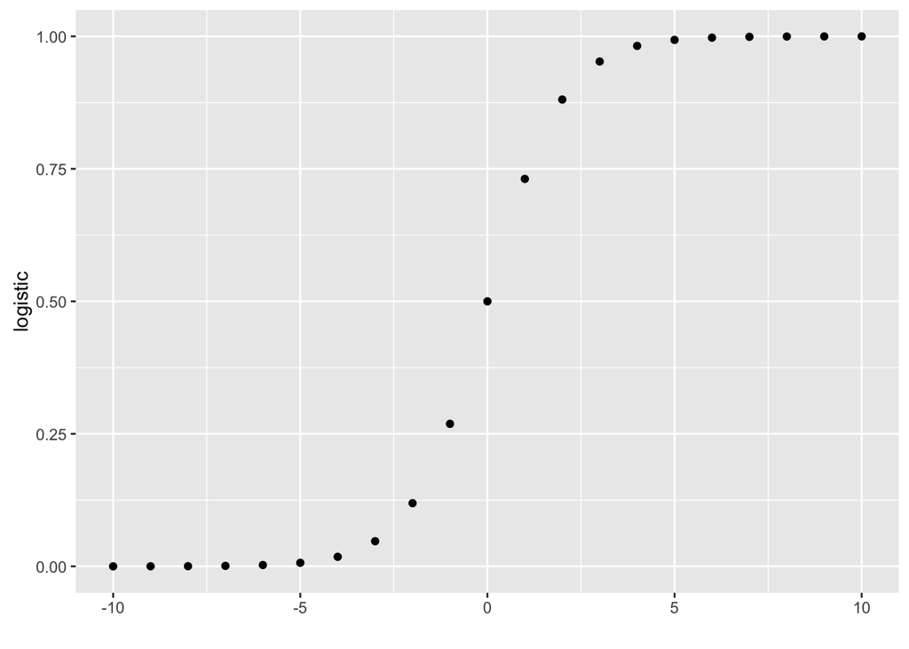

```r
logistic <- function(x) {
  1/(1 + exp(-x))
}

qplot(x=c(-10:10), y =logistic(c(-10:10)), xlab="", ylab="logistic")
```

```r
logistic_inv <- function(y) {
  uniroot(logistic, c(0.1,100), extendInt="yes")
}

#qplot(x=c(0, 1), y =logistic_inv(c(0.1, 1)), xlab="", ylab="inverse of logistic")
```

**NOTE“** These functions are quite handy, in evaluating logistic regression results. You may want to save these functions in your own package.

```r
# DO NOT EDIT
c(-Inf,0,Inf) %>% logistic
```

```
## [1] 0.0 0.5 1.0
```

```r
c(0,0.5,1) %>% logistic_inv
```

```
## $root
## [1] -1048.475
##
## $f.root
## [1] 0
##
## $iter
## [1] 20
##
## $init.it
## [1] 20
##
## $estim.prec
## [1] 0
```

## German Credit Model

Using the GermanCredit data from the **Caret** package/ UCI Machine Learning Library, create a model for `Class` (“Good” vs. “Bad” ). Show your model performance.

```r
library(caret)
data(GermanCredit)
fit.glm <- glm(Class ~  ., data=GermanCredit, family="binomial")
fit.glm.both.directions <- stepAIC(fit.glm, data=GermanCredit, direction = "both")
```

```
## Start:  AIC=993.82
## Class ~ Duration + Amount + InstallmentRatePercentage + ResidenceDuration +
##     Age + NumberExistingCredits + NumberPeopleMaintenance + Telephone +
##     ForeignWorker + CheckingAccountStatus.lt.0 + CheckingAccountStatus.0.to.200 +
##     CheckingAccountStatus.gt.200 + CheckingAccountStatus.none +
##     CreditHistory.NoCredit.AllPaid + CreditHistory.ThisBank.AllPaid +
##     CreditHistory.PaidDuly + CreditHistory.Delay + CreditHistory.Critical +
##     Purpose.NewCar + Purpose.UsedCar + Purpose.Furniture.Equipment +
##     Purpose.Radio.Television + Purpose.DomesticAppliance + Purpose.Repairs +
##     Purpose.Education + Purpose.Vacation + Purpose.Retraining +
##     Purpose.Business + Purpose.Other + SavingsAccountBonds.lt.100 +
##     SavingsAccountBonds.100.to.500 + SavingsAccountBonds.500.to.1000 +
##     SavingsAccountBonds.gt.1000 + SavingsAccountBonds.Unknown +
##     EmploymentDuration.lt.1 + EmploymentDuration.1.to.4 + EmploymentDuration.4.to.7 +
##     EmploymentDuration.gt.7 + EmploymentDuration.Unemployed +
##     Personal.Male.Divorced.Seperated + Personal.Female.NotSingle +
##     Personal.Male.Single + Personal.Male.Married.Widowed + Personal.Female.Single +
##     OtherDebtorsGuarantors.None + OtherDebtorsGuarantors.CoApplicant +
##     OtherDebtorsGuarantors.Guarantor + Property.RealEstate +
##     Property.Insurance + Property.CarOther + Property.Unknown +
##     OtherInstallmentPlans.Bank + OtherInstallmentPlans.Stores +
##     OtherInstallmentPlans.None + Housing.Rent + Housing.Own +
##     Housing.ForFree + Job.UnemployedUnskilled + Job.UnskilledResident +
##     Job.SkilledEmployee + Job.Management.SelfEmp.HighlyQualified
##
##
## Step:  AIC=993.82
## Class ~ Duration + Amount + InstallmentRatePercentage + ResidenceDuration +
##     Age + NumberExistingCredits + NumberPeopleMaintenance + Telephone +
##     ForeignWorker + CheckingAccountStatus.lt.0 + CheckingAccountStatus.0.to.200 +
##     CheckingAccountStatus.gt.200 + CheckingAccountStatus.none +
##     CreditHistory.NoCredit.AllPaid + CreditHistory.ThisBank.AllPaid +
##     CreditHistory.PaidDuly + CreditHistory.Delay + CreditHistory.Critical +
##     Purpose.NewCar + Purpose.UsedCar + Purpose.Furniture.Equipment +
##     Purpose.Radio.Television + Purpose.DomesticAppliance + Purpose.Repairs +
##     Purpose.Education + Purpose.Vacation + Purpose.Retraining +
##     Purpose.Business + Purpose.Other + SavingsAccountBonds.lt.100 +
##     SavingsAccountBonds.100.to.500 + SavingsAccountBonds.500.to.1000 +
##     SavingsAccountBonds.gt.1000 + SavingsAccountBonds.Unknown +
##     EmploymentDuration.lt.1 + EmploymentDuration.1.to.4 + EmploymentDuration.4.to.7 +
```

[output cut: 1902 more lines]

```
## - OtherDebtorsGuarantors.None             1   919.57  971.57
## - OtherInstallmentPlans.Bank              1   919.76  971.76
## - OtherDebtorsGuarantors.CoApplicant      1   919.95  971.95
## - Amount                                  1   920.61  972.61
## - EmploymentDuration.4.to.7               1   921.52  973.52
## - CreditHistory.PaidDuly                  1   922.83  974.83
## - CreditHistory.NoCredit.AllPaid          1   924.37  976.37
## - Duration                                1   924.68  976.68
## - InstallmentRatePercentage               1   926.40  978.40
## - Purpose.Education                       1   926.71  978.71
## - CreditHistory.ThisBank.AllPaid          1   928.32  980.32
## - SavingsAccountBonds.lt.100              1   931.43  983.43
## - Purpose.NewCar                          1   938.58  990.58
## - CheckingAccountStatus.0.to.200          1   947.40  999.40
## - CheckingAccountStatus.lt.0              1   978.43 1030.43
```

```r
summary(fit.glm.both.directions)
```

```
##
## Call:
## glm(formula = Class ~ Duration + Amount + InstallmentRatePercentage +
##     Age + ForeignWorker + CheckingAccountStatus.lt.0 + CheckingAccountStatus.0.to.200 +
##     CheckingAccountStatus.gt.200 + CreditHistory.NoCredit.AllPaid +
##     CreditHistory.ThisBank.AllPaid + CreditHistory.PaidDuly +
##     CreditHistory.Delay + Purpose.NewCar + Purpose.Furniture.Equipment +
##     Purpose.Radio.Television + Purpose.Repairs + Purpose.Education +
##     Purpose.Business + SavingsAccountBonds.lt.100 + SavingsAccountBonds.100.to.500 +
##     EmploymentDuration.4.to.7 + Personal.Male.Single + OtherDebtorsGuarantors.None +
##     OtherDebtorsGuarantors.CoApplicant + OtherInstallmentPlans.Bank +
##     Housing.Rent, family = "binomial", data = GermanCredit)
##
## Deviance Residuals:
##     Min       1Q   Median       3Q      Max
## -2.6100  -0.7425   0.3909   0.7175   2.3427
##
## Coefficients:
##                                      Estimate Std. Error z value Pr(>|z|)
## (Intercept)                         7.639e+00  9.291e-01   8.222  < 2e-16
## Duration                           -3.073e-02  8.870e-03  -3.464 0.000532
## Amount                             -1.131e-04  4.016e-05  -2.818 0.004839
## InstallmentRatePercentage          -3.089e-01  8.438e-02  -3.661 0.000251
## Age                                 1.441e-02  8.010e-03   1.799 0.072014
## ForeignWorker                      -1.389e+00  6.179e-01  -2.249 0.024530
## CheckingAccountStatus.lt.0         -1.759e+00  2.269e-01  -7.755 8.81e-15
## CheckingAccountStatus.0.to.200     -1.294e+00  2.244e-01  -5.766 8.13e-09
## CheckingAccountStatus.gt.200       -7.275e-01  3.751e-01  -1.939 0.052484
## CreditHistory.NoCredit.AllPaid     -1.436e+00  4.261e-01  -3.370 0.000752
## CreditHistory.ThisBank.AllPaid     -1.537e+00  3.929e-01  -3.912 9.16e-05
## CreditHistory.PaidDuly             -6.676e-01  2.123e-01  -3.144 0.001664
## CreditHistory.Delay                -5.933e-01  3.236e-01  -1.833 0.066787
## Purpose.NewCar                     -1.511e+00  3.108e-01  -4.863 1.16e-06
## Purpose.Furniture.Equipment        -7.862e-01  3.240e-01  -2.427 0.015240
## Purpose.Radio.Television           -6.100e-01  3.208e-01  -1.902 0.057203
## Purpose.Repairs                    -1.366e+00  5.803e-01  -2.353 0.018608
## Purpose.Education                  -1.641e+00  4.404e-01  -3.725 0.000195
## Purpose.Business                   -7.597e-01  3.765e-01  -2.018 0.043600
## SavingsAccountBonds.lt.100         -9.007e-01  2.135e-01  -4.219 2.46e-05
## SavingsAccountBonds.100.to.500     -6.437e-01  3.090e-01  -2.083 0.037246
```

[output cut: 29 more lines]

```
## Personal.Male.Single               **
## OtherDebtorsGuarantors.None        *
## OtherDebtorsGuarantors.CoApplicant **
## OtherInstallmentPlans.Bank         **
## Housing.Rent                       .
## ---
## Signif. codes:  0 '***' 0.001 '**' 0.01 '*' 0.05 '.' 0.1 ' ' 1
##
## (Dispersion parameter for binomial family taken to be 1)
##
##     Null deviance: 1221.73  on 999  degrees of freedom
## Residual deviance:  912.57  on 973  degrees of freedom
## AIC: 966.57
##
## Number of Fisher Scoring iterations: 5
```

## Iterative Correlated Feature Removal

- Implement Kuhn’s iterative feature removal function described in **APM** Section 3.5, page 47

```r
feature_removal <- function(cor_matrix, threshold) {
 # find predictors that are highly correlated
 diag(cor_matrix) <- 0 # self correlations (1.0) won't be considered
 max_matrix <- which(cor_matrix == max(abs(cor_matrix)), arr.ind = TRUE)
 cols_corr_predictors <- max_matrix[,1] # columns of the strongly correlated predictors
 predictor1_col <- cols_corr_predictors[1]
 predictor2_col <- cols_corr_predictors[2]
 high_corr <- cor_matrix[predictor1_col, predictor2_col]

 # checks for stop condition
 if (high_corr > threshold) {
   # average correlation to the other predictors
   predictor1_mean <- mean(cor_matrix[predictor1_col])
   predictor2_mean <- mean(cor_matrix[predictor2_col])

   # determine the predictor with the higher correlation with the other predictors
   highest_corr_predictor <- predictor1_col
   if (predictor2_mean > predictor1_mean) {
     highest_corr_predictor <- predictor2_col
   }

   # recursive call until the stop condition meets
   col_row_remove <- -1 * highest_corr_predictor
   cor_matrix_new <- cor_matrix[col_row_remove, col_row_remove]
   feature_removal(cor_matrix_new, threshold)
 }
}

find_features <- function(x, threshold) {
  # calculate correlations
  cor_matrix <- cor(x)

  feature_removal(cor_matrix, threshold)
}
```

- Usage of above function: find_features(iris[-5], threshold=0.9)
- The function is not completely working yet..

## Synthetic Data (Optional)

Sometimes it is useful to “synthesize” feature data for to understand how a certain model behaves. Sythesize the following features 1000-element vectors:

- x1: a normally distributed variable with `mean = 20` and standard deviation = 20 (`sd=8`).
- x2: a log-normally distributed feature with `meanlog = 1`, `sdlog=1.2`
- x3: a uniformly distributed feature with `min=0` and `max=50`.

```r
nsamples = 20

x1 <- rnorm(nsamples,20,20)
x2 <- rlnorm(nsamples, meanlog=1, sdlog = 1.2)
x3 <- runif(nsamples,0,50)
```

Next synthesis a response, `y` using the betas provided and an intercept that is normally distributed at 20 with standard deviation of 2. (**Hint:** The betas thought of can be a vector or matrix)

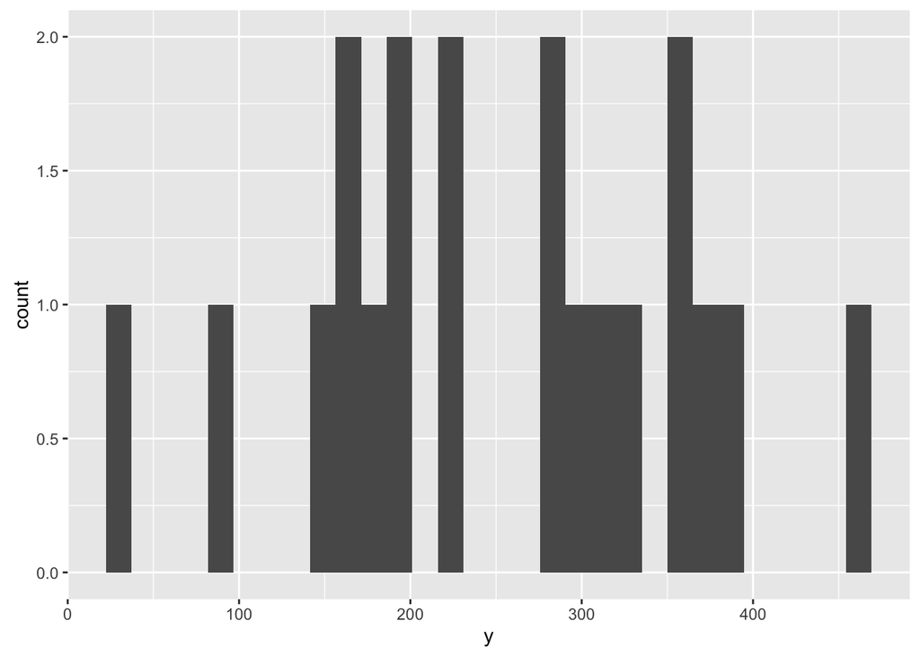

```r
beta0 <- rnorm(nsamples,0,15)  # intercept!
beta1 <- 2.3
beta2 <- 4
beta3 <- 7

betas <- matrix( c(2.5, 4, 7), nrow=1  )  # 1x4 matrix

# x0 <- rep(1,nsamples)

X  <- cbind(x1,x2,x3)  # 1000x4

y <- betas %*% t(X) %>% t
y <- y + beta0

qplot(y)
```

```r
dat <- data.frame(y,X)

fit <- lm( y ~ . , dat )

coef(fit)
```

```
## (Intercept)          x1          x2          x3
##  -11.920478    2.634658    4.445864    7.289189
```

```r
fit
```

```
##
## Call:
## lm(formula = y ~ ., data = dat)
##
## Coefficients:
## (Intercept)           x1           x2           x3
##     -11.920        2.635        4.446        7.289
```

- Did you recover the betas?
- Is the model good?
- What happens if increase the value of `nsamples`? Decrease it?
- What transformations would you apply to x1? x2? x3?